# On this notebook the best models and input parameters will be searched for. The problem at hand is predicting the price of any stock symbol 7 days ahead, assuming one model for all the symbols. The be

## Let's evaluate the Dummy predictor (mean of the base period) with the first parameters set

```
Evaluating approximately 175 training/evaluation pairs
Approximately 100.0 percent complete.    r2 shape: (175, 2)
mre shape: (175, 2)
y_val_true_df shape: (49875, 1)
y_val_pred_df shape: (49875, 1)
mean_dates shape (175,)


            r2       mre
AAPL  0.328390  0.035374
ABT   0.331975  0.064653
ADBE  0.278604  0.040468
ADM   0.297788  0.063628
ADP   0.248441  0.056747


----------------------------------------------------------------------
The mean metrics are:
r2     0.304831
mre    0.046136
dtype: float64
----------------------------------------------------------------------
Elapsed time: 104.84337615966797 seconds
```

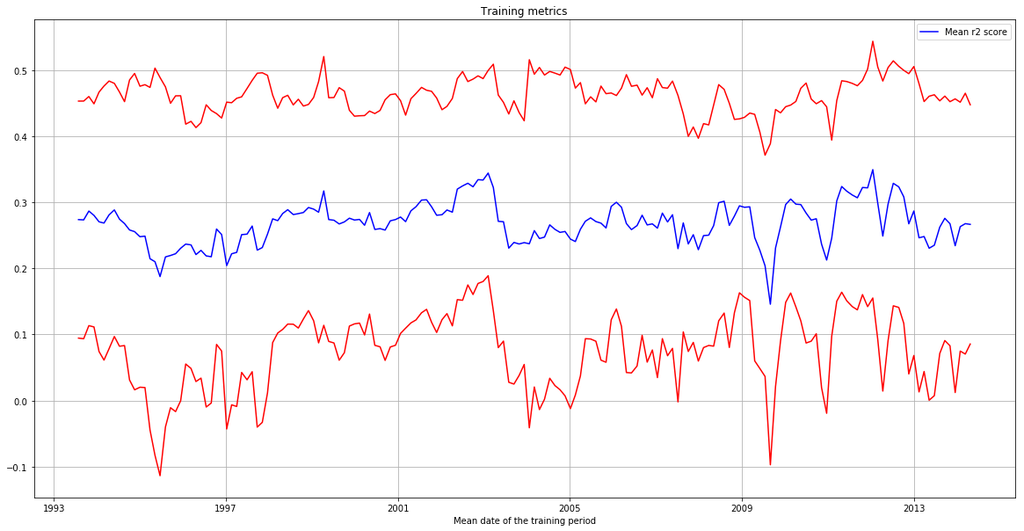

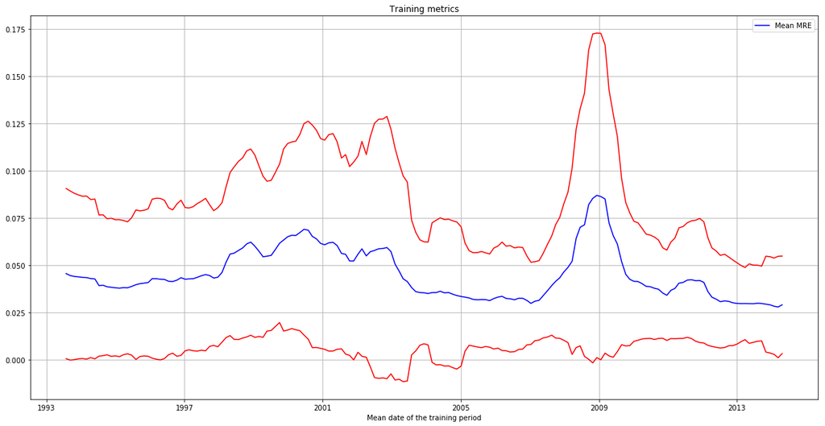

```python
tic = time()

train_days = 252  # The amount of market days for each training period
step_eval_days = 30  # The step to move between training/validation pairs

from predictor.dummy_mean_predictor import DummyPredictor
dummy_predictor = DummyPredictor()

import predictor.evaluation as ev
r2, mre, y_val_true_df, y_val_pred_df, mean_dates = ev.roll_evaluate(x,
                                                                     y,
                                                                     train_days,
                                                                     step_eval_days,
                                                                     ahead_days,
                                                                     dummy_predictor,
                                                                     verbose=True)
print('r2 shape: {}'.format(r2.shape))
print('mre shape: {}'.format(mre.shape))
print('y_val_true_df shape: {}'.format(y_val_true_df.shape))
print('y_val_pred_df shape: {}'.format(y_val_pred_df.shape))
print('mean_dates shape {}'.format(mean_dates.shape))

plt.plot(mean_dates, r2[:, 0], 'b', label='Mean r2 score')
plt.plot(mean_dates, r2[:, 0] + 2*r2[:, 1], 'r')
plt.plot(mean_dates, r2[:, 0] - 2*r2[:, 1], 'r')
plt.xlabel('Mean date of the training period')
plt.legend()
plt.title('Training metrics')
plt.grid()

plt.figure()
plt.plot(mean_dates, mre[:, 0], 'b', label='Mean MRE')
plt.plot(mean_dates, mre[:, 0] + 2*mre[:, 1], 'r')
plt.plot(mean_dates, mre[:, 0] - 2*mre[:, 1], 'r')
plt.xlabel('Mean date of the training period')
plt.legend()
plt.title('Training metrics')
plt.grid()

print('\n')
val_metrics_df = ev.get_metrics_df(y_val_true_df, y_val_pred_df)
print(val_metrics_df.head())
print('\n\n' + '-'*70)
print('The mean metrics are: \n{}'.format(val_metrics_df.mean()))
print('-'*70)

toc = time()
print('Elapsed time: {} seconds'.format((toc-tic)))
```

## Let's see if a linear regression can improve that.

```
Evaluating approximately 175 training/evaluation pairs
Approximately 100.0 percent complete.    r2 shape: (175, 2)
mre shape: (175, 2)
y_val_true_df shape: (49875, 1)
y_val_pred_df shape: (49875, 1)
mean_dates shape (175,)


            r2       mre
AAPL  0.454196  0.031715
ABT   0.363873  0.061779
ADBE  0.391297  0.035971
ADM   0.584289  0.048295
ADP   0.275147  0.052664


----------------------------------------------------------------------
The mean metrics are:
r2     0.417156
mre    0.041709
dtype: float64
----------------------------------------------------------------------
Elapsed time: 105.64992165565491 seconds
```

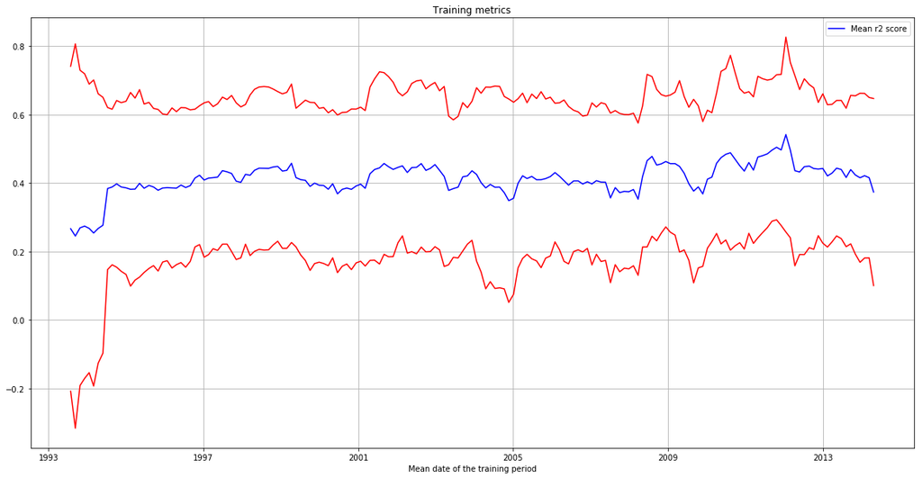

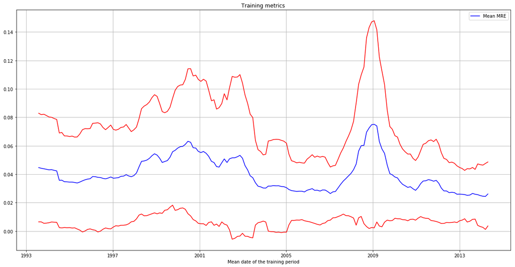

```python
tic = time()

from predictor.linear_predictor import LinearPredictor
eval_predictor = LinearPredictor()

train_days = 252  # The amount of market days for each training period
step_eval_days = 30  # The step to move between training/validation pairs

import predictor.evaluation as ev
r2, mre, y_val_true_df, y_val_pred_df, mean_dates = ev.roll_evaluate(x,
                                                                     y,
                                                                     train_days,
                                                                     step_eval_days,
                                                                     ahead_days,
                                                                     eval_predictor,
                                                                     verbose=True)
print('r2 shape: {}'.format(r2.shape))
print('mre shape: {}'.format(mre.shape))
print('y_val_true_df shape: {}'.format(y_val_true_df.shape))
print('y_val_pred_df shape: {}'.format(y_val_pred_df.shape))
print('mean_dates shape {}'.format(mean_dates.shape))

plt.plot(mean_dates, r2[:, 0], 'b', label='Mean r2 score')
plt.plot(mean_dates, r2[:, 0] + 2*r2[:, 1], 'r')
plt.plot(mean_dates, r2[:, 0] - 2*r2[:, 1], 'r')
plt.xlabel('Mean date of the training period')
plt.legend()
plt.title('Training metrics')
plt.grid()

plt.figure()
plt.plot(mean_dates, mre[:, 0], 'b', label='Mean MRE')
plt.plot(mean_dates, mre[:, 0] + 2*mre[:, 1], 'r')
plt.plot(mean_dates, mre[:, 0] - 2*mre[:, 1], 'r')
plt.xlabel('Mean date of the training period')
plt.legend()
plt.title('Training metrics')
plt.grid()


print('\n')
val_metrics_df = ev.get_metrics_df(y_val_true_df, y_val_pred_df)
print(val_metrics_df.head())
print('\n\n' + '-'*70)
print('The mean metrics are: \n{}'.format(val_metrics_df.mean()))
print('-'*70)

toc = time()
print('Elapsed time: {} seconds'.format((toc-tic)))
```

## Let's try to find the best base period and training period for the Linear Regressor.

```python
datasets_params_list_df.head()
```

|  | base_days | ahead_days | train_val_time | step_days | GOOD_DATA_RATIO | SAMPLES_GOOD_DATA_RATIO | x_filename | y_filename |
| --- | --- | --- | --- | --- | --- | --- | --- | --- |
| 0 | 7 | 1 | -1 | 7 | 0.99 | 0.9 | x_base7_ahead1.pkl | y_base7_ahead1.pkl |
| 1 | 7 | 7 | -1 | 7 | 0.99 | 0.9 | x_base7_ahead7.pkl | y_base7_ahead7.pkl |
| 2 | 7 | 14 | -1 | 7 | 0.99 | 0.9 | x_base7_ahead14.pkl | y_base7_ahead14.pkl |
| 3 | 7 | 28 | -1 | 7 | 0.99 | 0.9 | x_base7_ahead28.pkl | y_base7_ahead28.pkl |
| 4 | 7 | 56 | -1 | 7 | 0.99 | 0.9 | x_base7_ahead56.pkl | y_base7_ahead56.pkl |

```python
lin_reg_results = datasets_params_list_df.copy()  # To store the results of the r2 score and mre.
```

```python
train_days_arr = 252 * np.array([1, 2, 3])
train_days_arr
```

```
array([252, 504, 756])
```

## Let's create a parameters list for roll evaluation. We should keep only the param sets with ahead_days=7, and also add different triaining periods.

```python
params_list_7_df = datasets_params_list_df[datasets_params_list_df['ahead_days'] == 7]
params_list_7_df
```

|  | base_days | ahead_days | train_val_time | step_days | GOOD_DATA_RATIO | SAMPLES_GOOD_DATA_RATIO | x_filename | y_filename |
| --- | --- | --- | --- | --- | --- | --- | --- | --- |
| 1 | 7 | 7 | -1 | 7 | 0.99 | 0.9 | x_base7_ahead7.pkl | y_base7_ahead7.pkl |
| 6 | 14 | 7 | -1 | 7 | 0.99 | 0.9 | x_base14_ahead7.pkl | y_base14_ahead7.pkl |
| 11 | 28 | 7 | -1 | 7 | 0.99 | 0.9 | x_base28_ahead7.pkl | y_base28_ahead7.pkl |
| 16 | 56 | 7 | -1 | 7 | 0.99 | 0.9 | x_base56_ahead7.pkl | y_base56_ahead7.pkl |
| 21 | 112 | 7 | -1 | 7 | 0.99 | 0.9 | x_base112_ahead7.pkl | y_base112_ahead7.pkl |

```python
params_list_df = pd.DataFrame()

for train_days in train_days_arr:
    temp_df = params_list_7_df.copy()
    temp_df['train_days'] = train_days
    params_list_df = params_list_df.append(temp_df, ignore_index=True)
```

```python
params_list_df
```

|  | base_days | ahead_days | train_val_time | step_days | GOOD_DATA_RATIO | SAMPLES_GOOD_DATA_RATIO | x_filename | y_filename | train_days |
| --- | --- | --- | --- | --- | --- | --- | --- | --- | --- |
| 0 | 7 | 7 | -1 | 7 | 0.99 | 0.9 | x_base7_ahead7.pkl | y_base7_ahead7.pkl | 252 |
| 1 | 14 | 7 | -1 | 7 | 0.99 | 0.9 | x_base14_ahead7.pkl | y_base14_ahead7.pkl | 252 |
| 2 | 28 | 7 | -1 | 7 | 0.99 | 0.9 | x_base28_ahead7.pkl | y_base28_ahead7.pkl | 252 |
| 3 | 56 | 7 | -1 | 7 | 0.99 | 0.9 | x_base56_ahead7.pkl | y_base56_ahead7.pkl | 252 |
| 4 | 112 | 7 | -1 | 7 | 0.99 | 0.9 | x_base112_ahead7.pkl | y_base112_ahead7.pkl | 252 |
| 5 | 7 | 7 | -1 | 7 | 0.99 | 0.9 | x_base7_ahead7.pkl | y_base7_ahead7.pkl | 504 |
| 6 | 14 | 7 | -1 | 7 | 0.99 | 0.9 | x_base14_ahead7.pkl | y_base14_ahead7.pkl | 504 |
| 7 | 28 | 7 | -1 | 7 | 0.99 | 0.9 | x_base28_ahead7.pkl | y_base28_ahead7.pkl | 504 |
| 8 | 56 | 7 | -1 | 7 | 0.99 | 0.9 | x_base56_ahead7.pkl | y_base56_ahead7.pkl | 504 |
| 9 | 112 | 7 | -1 | 7 | 0.99 | 0.9 | x_base112_ahead7.pkl | y_base112_ahead7.pkl | 504 |
| 10 | 7 | 7 | -1 | 7 | 0.99 | 0.9 | x_base7_ahead7.pkl | y_base7_ahead7.pkl | 756 |
| 11 | 14 | 7 | -1 | 7 | 0.99 | 0.9 | x_base14_ahead7.pkl | y_base14_ahead7.pkl | 756 |
| 12 | 28 | 7 | -1 | 7 | 0.99 | 0.9 | x_base28_ahead7.pkl | y_base28_ahead7.pkl | 756 |
| 13 | 56 | 7 | -1 | 7 | 0.99 | 0.9 | x_base56_ahead7.pkl | y_base56_ahead7.pkl | 756 |
| 14 | 112 | 7 | -1 | 7 | 0.99 | 0.9 | x_base112_ahead7.pkl | y_base112_ahead7.pkl | 756 |

## Let's define a function that returns the mean r^2 and mre for a roll evaluation

```python
import predictor.evaluation as ev

def mean_score_eval(params):
    # Input values
    train_days = int(params['train_days'])

    GOOD_DATA_RATIO, \
    train_val_time, \
    base_days, \
    step_days, \
    ahead_days, \
    SAMPLES_GOOD_DATA_RATIO, \
    x_filename, \
    y_filename = unpack_params(params)

    pid = 'base{}_ahead{}_train{}'.format(base_days, ahead_days, train_days)
    print('Generating: {}'.format(pid))

    # Getting the data
    x = pd.read_pickle('../../data/{}'.format(x_filename))
    y = pd.read_pickle('../../data/{}'.format(y_filename))

    r2, mre, y_val_true_df, y_val_pred_df, mean_dates = ev.roll_evaluate(x,
                                                                         y,
                                                                         train_days,
                                                                         step_eval_days,
                                                                         ahead_days,
                                                                         eval_predictor,
                                                                         verbose=True)
    val_metrics_df = ev.get_metrics_df(y_val_true_df, y_val_pred_df)
    #return (pid, pid)
    result = tuple(val_metrics_df.mean().values)
    print(result)
    return result
```

```python
def apply_mean_score_eval(params_df):
    result_df = params_df.copy()
    result_df['scores'] = result_df.apply(mean_score_eval, axis=1)
    return result_df
```

### Let's test the single params set function

```python
# Global variables
eval_predictor = LinearPredictor()
step_eval_days = 30  # The step to move between training/validation pairs
```

```python
test_params_df = params_list_df.iloc[0,:]
test_params_df
```

```
base_days                                   7
ahead_days                                  7
train_val_time                             -1
step_days                                   7
GOOD_DATA_RATIO                          0.99
SAMPLES_GOOD_DATA_RATIO                   0.9
x_filename                 x_base7_ahead7.pkl
y_filename                 y_base7_ahead7.pkl
train_days                                252
Name: 0, dtype: object
```

```python
scores_tuple = mean_score_eval(test_params_df)
```

```
Generating: base7_ahead7_train252
Evaluating approximately 175 training/evaluation pairs
Approximately 100.0 percent complete.    (0.41715645632362724, 0.041709143645833072)
```

```python
scores_tuple
```

```
(0.41715645632362724, 0.041709143645833072)
```

### Now with two params sets

```python
test_params_df = params_list_df.iloc[0:2,:]
test_params_df
```

|  | base_days | ahead_days | train_val_time | step_days | GOOD_DATA_RATIO | SAMPLES_GOOD_DATA_RATIO | x_filename | y_filename | train_days |
| --- | --- | --- | --- | --- | --- | --- | --- | --- | --- |
| 0 | 7 | 7 | -1 | 7 | 0.99 | 0.9 | x_base7_ahead7.pkl | y_base7_ahead7.pkl | 252 |
| 1 | 14 | 7 | -1 | 7 | 0.99 | 0.9 | x_base14_ahead7.pkl | y_base14_ahead7.pkl | 252 |

```python
res_df = apply_mean_score_eval(test_params_df)
res_df
```

```
Generating: base7_ahead7_train252
Evaluating approximately 175 training/evaluation pairs
Approximately 100.0 percent complete.    (0.41715645632362724, 0.041709143645833072)
Generating: base14_ahead7_train252
Evaluating approximately 175 training/evaluation pairs
Approximately 100.0 percent complete.    (0.590584834225091, 0.039970562390476291)
```

|  | base_days | ahead_days | train_val_time | step_days | GOOD_DATA_RATIO | SAMPLES_GOOD_DATA_RATIO | x_filename | y_filename | train_days | scores |
| --- | --- | --- | --- | --- | --- | --- | --- | --- | --- | --- |
| 0 | 7 | 7 | -1 | 7 | 0.99 | 0.9 | x_base7_ahead7.pkl | y_base7_ahead7.pkl | 252 | (0.417156456324, 0.0417091436458) |
| 1 | 14 | 7 | -1 | 7 | 0.99 | 0.9 | x_base14_ahead7.pkl | y_base14_ahead7.pkl | 252 | (0.590584834225, 0.0399705623905) |

## Finally, let's parallellize the evaluation. (some code and suggestions were taken from here: http://www.racketracer.com/2016/07/06/pandas-in-parallel/#comments)

```python
from multiprocessing import Pool

num_partitions = 4 #number of partitions to split dataframe
num_cores = 4 #number of cores on your machine

def parallelize_dataframe(df, func):
    df_split = np.array_split(df, num_partitions)
    pool = Pool(num_cores)
    df = pd.concat(pool.map(func, df_split))
    pool.close()
    pool.join()
    return df
```

```python
from predictor.linear_predictor import LinearPredictor

# Global variables
eval_predictor = LinearPredictor()
step_eval_days = 30  # The step to move between training/validation pairs


results_df = parallelize_dataframe(params_list_df, apply_mean_score_eval)
results_df
```

```
Generating: base7_ahead7_train252
Generating: base112_ahead7_train252
Generating: base28_ahead7_train756
Generating: base56_ahead7_train504
Evaluating approximately 175 training/evaluation pairs
Evaluating approximately 157 training/evaluation pairs
Evaluating approximately 165 training/evaluation pairs
Evaluating approximately 171 training/evaluation pairs
Approximately 96.5 percent complete.     (0.41715645632362724, 0.041709143645833072)
Generating: base14_ahead7_train252
Approximately 90.3 percent complete.    Evaluating approximately 175 training/evaluation pairs
Approximately 4.0 percent complete.      (0.90711125643138013, 0.045839360334416858)
Generating: base7_ahead7_train504
Approximately 4.6 percent complete.     Evaluating approximately 166 training/evaluation pairs
Approximately 98.1 percent complete.     (0.85819094903096438, 0.04177329583752791)
Generating: base112_ahead7_train504
Approximately 11.4 percent complete.    Evaluating approximately 163 training/evaluation pairs
Approximately 9.0 percent complete.      (0.76270070300970916, 0.041464521310968179)
Generating: base56_ahead7_train756
Approximately 14.9 percent complete.    Evaluating approximately 156 training/evaluation pairs
Approximately 90.4 percent complete.     (0.590584834225091, 0.039970562390476291)
Generating: base28_ahead7_train252
Approximately 73.1 percent complete.    Evaluating approximately 174 training/evaluation pairs
Approximately 85.9 percent complete.     (0.44919366599456434, 0.04031478164200597)
Generating: base14_ahead7_train504
Approximately 82.7 percent complete.    Evaluating approximately 166 training/evaluation pairs
Approximately 28.7 percent complete.     (0.91952015805737286, 0.043625725762939202)
Generating: base7_ahead7_train756
Approximately 29.3 percent complete.    Evaluating approximately 158 training/evaluation pairs
Approximately 33.3 percent complete.     (0.86064760076906088, 0.042249101154728297)
Generating: base112_ahead7_train756
Approximately 33.9 percent complete.    Evaluating approximately 155 training/evaluation pairs
Approximately 64.6 percent complete.     (0.72299823991805656, 0.042870567971245915)
Generating: base56_ahead7_train252
Approximately 65.2 percent complete.    Evaluating approximately 173 training/evaluation pairs
Approximately 19.7 percent complete.     (0.63702090184181126, 0.040413208201006252)
Approximately 83.5 percent complete.    Generating: base28_ahead7_train504
Approximately 20.2 percent complete.    Evaluating approximately 166 training/evaluation pairs
Approximately 39.3 percent complete.     (0.43669280310958536, 0.04116221744345152)
Generating: base14_ahead7_train756
Approximately 17.5 percent complete.    Evaluating approximately 158 training/evaluation pairs
Approximately 22.2 percent complete.     (0.92334783833104883, 0.042367035521893887)
Approximately 55.7 percent complete.     (0.84248709472664118, 0.043117159409191169)
Approximately 100.0 percent complete.    (0.7634451923858151, 0.04238685859279117)
Approximately 100.0 percent complete.    (0.62490461976459089, 0.041463577326952245)
```

|  | base_days | ahead_days | train_val_time | step_days | GOOD_DATA_RATIO | SAMPLES_GOOD_DATA_RATIO | x_filename | y_filename | train_days | scores |
| --- | --- | --- | --- | --- | --- | --- | --- | --- | --- | --- |
| 0 | 7 | 7 | -1 | 7 | 0.99 | 0.9 | x_base7_ahead7.pkl | y_base7_ahead7.pkl | 252 | (0.417156456324, 0.0417091436458) |
| 1 | 14 | 7 | -1 | 7 | 0.99 | 0.9 | x_base14_ahead7.pkl | y_base14_ahead7.pkl | 252 | (0.590584834225, 0.0399705623905) |
| 2 | 28 | 7 | -1 | 7 | 0.99 | 0.9 | x_base28_ahead7.pkl | y_base28_ahead7.pkl | 252 | (0.722998239918, 0.0428705679712) |
| 3 | 56 | 7 | -1 | 7 | 0.99 | 0.9 | x_base56_ahead7.pkl | y_base56_ahead7.pkl | 252 | (0.842487094727, 0.0431171594092) |
| 4 | 112 | 7 | -1 | 7 | 0.99 | 0.9 | x_base112_ahead7.pkl | y_base112_ahead7.pkl | 252 | (0.907111256431, 0.0458393603344) |
| 5 | 7 | 7 | -1 | 7 | 0.99 | 0.9 | x_base7_ahead7.pkl | y_base7_ahead7.pkl | 504 | (0.449193665995, 0.040314781642) |
| 6 | 14 | 7 | -1 | 7 | 0.99 | 0.9 | x_base14_ahead7.pkl | y_base14_ahead7.pkl | 504 | (0.637020901842, 0.040413208201) |
| 7 | 28 | 7 | -1 | 7 | 0.99 | 0.9 | x_base28_ahead7.pkl | y_base28_ahead7.pkl | 504 | (0.763445192386, 0.0423868585928) |
| 8 | 56 | 7 | -1 | 7 | 0.99 | 0.9 | x_base56_ahead7.pkl | y_base56_ahead7.pkl | 504 | (0.858190949031, 0.0417732958375) |
| 9 | 112 | 7 | -1 | 7 | 0.99 | 0.9 | x_base112_ahead7.pkl | y_base112_ahead7.pkl | 504 | (0.919520158057, 0.0436257257629) |
| 10 | 7 | 7 | -1 | 7 | 0.99 | 0.9 | x_base7_ahead7.pkl | y_base7_ahead7.pkl | 756 | (0.43669280311, 0.0411622174435) |
| 11 | 14 | 7 | -1 | 7 | 0.99 | 0.9 | x_base14_ahead7.pkl | y_base14_ahead7.pkl | 756 | (0.624904619765, 0.041463577327) |
| 12 | 28 | 7 | -1 | 7 | 0.99 | 0.9 | x_base28_ahead7.pkl | y_base28_ahead7.pkl | 756 | (0.76270070301, 0.041464521311) |
| 13 | 56 | 7 | -1 | 7 | 0.99 | 0.9 | x_base56_ahead7.pkl | y_base56_ahead7.pkl | 756 | (0.860647600769, 0.0422491011547) |
| 14 | 112 | 7 | -1 | 7 | 0.99 | 0.9 | x_base112_ahead7.pkl | y_base112_ahead7.pkl | 756 | (0.923347838331, 0.0423670355219) |

```python
results_df['r2'] = results_df.apply(lambda x: x['scores'][0], axis=1)
results_df['mre'] = results_df.apply(lambda x: x['scores'][1], axis=1)
results_df
```

|  | base_days | ahead_days | train_val_time | step_days | GOOD_DATA_RATIO | SAMPLES_GOOD_DATA_RATIO | x_filename | y_filename | train_days | scores | r2 | mre |
| --- | --- | --- | --- | --- | --- | --- | --- | --- | --- | --- | --- | --- |
| 0 | 7 | 7 | -1 | 7 | 0.99 | 0.9 | x_base7_ahead7.pkl | y_base7_ahead7.pkl | 252 | (0.417156456324, 0.0417091436458) | 0.417156 | 0.041709 |
| 1 | 14 | 7 | -1 | 7 | 0.99 | 0.9 | x_base14_ahead7.pkl | y_base14_ahead7.pkl | 252 | (0.590584834225, 0.0399705623905) | 0.590585 | 0.039971 |
| 2 | 28 | 7 | -1 | 7 | 0.99 | 0.9 | x_base28_ahead7.pkl | y_base28_ahead7.pkl | 252 | (0.722998239918, 0.0428705679712) | 0.722998 | 0.042871 |
| 3 | 56 | 7 | -1 | 7 | 0.99 | 0.9 | x_base56_ahead7.pkl | y_base56_ahead7.pkl | 252 | (0.842487094727, 0.0431171594092) | 0.842487 | 0.043117 |
| 4 | 112 | 7 | -1 | 7 | 0.99 | 0.9 | x_base112_ahead7.pkl | y_base112_ahead7.pkl | 252 | (0.907111256431, 0.0458393603344) | 0.907111 | 0.045839 |
| 5 | 7 | 7 | -1 | 7 | 0.99 | 0.9 | x_base7_ahead7.pkl | y_base7_ahead7.pkl | 504 | (0.449193665995, 0.040314781642) | 0.449194 | 0.040315 |
| 6 | 14 | 7 | -1 | 7 | 0.99 | 0.9 | x_base14_ahead7.pkl | y_base14_ahead7.pkl | 504 | (0.637020901842, 0.040413208201) | 0.637021 | 0.040413 |
| 7 | 28 | 7 | -1 | 7 | 0.99 | 0.9 | x_base28_ahead7.pkl | y_base28_ahead7.pkl | 504 | (0.763445192386, 0.0423868585928) | 0.763445 | 0.042387 |
| 8 | 56 | 7 | -1 | 7 | 0.99 | 0.9 | x_base56_ahead7.pkl | y_base56_ahead7.pkl | 504 | (0.858190949031, 0.0417732958375) | 0.858191 | 0.041773 |
| 9 | 112 | 7 | -1 | 7 | 0.99 | 0.9 | x_base112_ahead7.pkl | y_base112_ahead7.pkl | 504 | (0.919520158057, 0.0436257257629) | 0.919520 | 0.043626 |
| 10 | 7 | 7 | -1 | 7 | 0.99 | 0.9 | x_base7_ahead7.pkl | y_base7_ahead7.pkl | 756 | (0.43669280311, 0.0411622174435) | 0.436693 | 0.041162 |
| 11 | 14 | 7 | -1 | 7 | 0.99 | 0.9 | x_base14_ahead7.pkl | y_base14_ahead7.pkl | 756 | (0.624904619765, 0.041463577327) | 0.624905 | 0.041464 |
| 12 | 28 | 7 | -1 | 7 | 0.99 | 0.9 | x_base28_ahead7.pkl | y_base28_ahead7.pkl | 756 | (0.76270070301, 0.041464521311) | 0.762701 | 0.041465 |
| 13 | 56 | 7 | -1 | 7 | 0.99 | 0.9 | x_base56_ahead7.pkl | y_base56_ahead7.pkl | 756 | (0.860647600769, 0.0422491011547) | 0.860648 | 0.042249 |
| 14 | 112 | 7 | -1 | 7 | 0.99 | 0.9 | x_base112_ahead7.pkl | y_base112_ahead7.pkl | 756 | (0.923347838331, 0.0423670355219) | 0.923348 | 0.042367 |

```python
# Pickle that!
results_df.to_pickle('../../data/results_ahead7_linear_df.pkl')
```

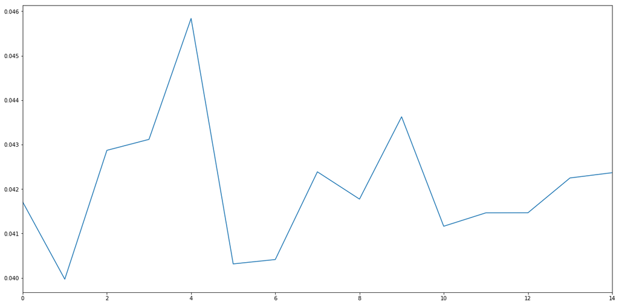

```python
results_df['mre'].plot()
```

```python
np.argmin(results_df['mre'])
```

```
1
```

```python
results_df.iloc[np.argmin(results_df['mre'])]
```

```
base_days                                                 14
ahead_days                                                 7
train_val_time                                            -1
step_days                                                  7
GOOD_DATA_RATIO                                         0.99
SAMPLES_GOOD_DATA_RATIO                                  0.9
x_filename                               x_base14_ahead7.pkl
y_filename                               y_base14_ahead7.pkl
train_days                                               252
scores                     (0.590584834225, 0.0399705623905)
r2                                                  0.590585
mre                                                0.0399706
Name: 1, dtype: object
```

```python
results_df.iloc[np.argmax(results_df['r2'])]
```

```
base_days                                                112
ahead_days                                                 7
train_val_time                                            -1
step_days                                                  7
GOOD_DATA_RATIO                                         0.99
SAMPLES_GOOD_DATA_RATIO                                  0.9
x_filename                              x_base112_ahead7.pkl
y_filename                              y_base112_ahead7.pkl
train_days                                               756
scores                     (0.923347838331, 0.0423670355219)
r2                                                  0.923348
mre                                                 0.042367
Name: 14, dtype: object
```

## The MRE is about 4.1% (that is better than the 5% target)

## Let's use other models...

### - KNN model

```python
from predictor.knn_predictor import KNNPredictor

# Global variables
eval_predictor = KNNPredictor()
step_eval_days = 30  # The step to move between training/validation pairs


results_df = parallelize_dataframe(params_list_df, apply_mean_score_eval)
results_df
```

```
Generating: base7_ahead7_train252
Generating: base112_ahead7_train252
Generating: base56_ahead7_train504
Generating: base28_ahead7_train756
Evaluating approximately 157 training/evaluation pairs
Evaluating approximately 175 training/evaluation pairs
Evaluating approximately 165 training/evaluation pairs
Evaluating approximately 171 training/evaluation pairs
Approximately 100.0 percent complete.    (0.1482816059271258, 0.046873135089328347)
Generating: base14_ahead7_train252
Approximately 8.2 percent complete.    Evaluating approximately 175 training/evaluation pairs
Approximately 100.0 percent complete.    (0.43910127879335292, 0.044254429060063771)
Generating: base28_ahead7_train252
Evaluating approximately 174 training/evaluation pairs
Approximately 100.6 percent complete.    (0.65203492488205406, 0.047218779365751196)
Generating: base56_ahead7_train252
Evaluating approximately 173 training/evaluation pairs
Approximately 100.6 percent complete.    (0.86401430873450868, 0.056346167936163115)
Generating: base7_ahead7_train504
Evaluating approximately 166 training/evaluation pairs
Approximately 100.6 percent complete.    (0.24585662085794285, 0.044981386267096059)
Generating: base14_ahead7_train504
Evaluating approximately 166 training/evaluation pairs
Approximately 100.6 percent complete.    (0.79592851781373175, 0.049771357502994343)
Approximately 100.6 percent complete.    (0.5215561809833601, 0.044662719384595963)
Generating: base28_ahead7_train504
Evaluating approximately 166 training/evaluation pairs
Approximately 100.0 percent complete.    (0.7995888867798383, 0.050716983073259912)
Generating: base112_ahead7_train504
Evaluating approximately 163 training/evaluation pairs
Approximately 6.7 percent complete.      (0.70928625317714855, 0.046076158482749388)
Generating: base56_ahead7_train756
Evaluating approximately 156 training/evaluation pairs
Approximately 100.0 percent complete.    (0.71339557395428699, 0.047451789637295301)
Approximately 100.6 percent complete.    (0.87141885887230919, 0.056029496136495542)
Generating: base7_ahead7_train756
Evaluating approximately 158 training/evaluation pairs
Approximately 100.6 percent complete.    (0.23410801831347966, 0.046588595084438501)
Generating: base14_ahead7_train756
Evaluating approximately 158 training/evaluation pairs
Approximately 100.0 percent complete.    (0.55080012168436687, 0.046052512188966076)
Approximately 100.6 percent complete.    (0.81587707228886797, 0.049406356321669204)
Generating: base112_ahead7_train756
Evaluating approximately 155 training/evaluation pairs
Approximately 100.0 percent complete.    (0.88179361362651398, 0.055444816807764037)
```

|  | base_days | ahead_days | train_val_time | step_days | GOOD_DATA_RATIO | SAMPLES_GOOD_DATA_RATIO | x_filename | y_filename | train_days | scores |
| --- | --- | --- | --- | --- | --- | --- | --- | --- | --- | --- |
| 0 | 7 | 7 | -1 | 7 | 0.99 | 0.9 | x_base7_ahead7.pkl | y_base7_ahead7.pkl | 252 | (0.148281605927, 0.0468731350893) |
| 1 | 14 | 7 | -1 | 7 | 0.99 | 0.9 | x_base14_ahead7.pkl | y_base14_ahead7.pkl | 252 | (0.439101278793, 0.0442544290601) |
| 2 | 28 | 7 | -1 | 7 | 0.99 | 0.9 | x_base28_ahead7.pkl | y_base28_ahead7.pkl | 252 | (0.652034924882, 0.0472187793658) |
| 3 | 56 | 7 | -1 | 7 | 0.99 | 0.9 | x_base56_ahead7.pkl | y_base56_ahead7.pkl | 252 | (0.795928517814, 0.049771357503) |
| 4 | 112 | 7 | -1 | 7 | 0.99 | 0.9 | x_base112_ahead7.pkl | y_base112_ahead7.pkl | 252 | (0.864014308735, 0.0563461679362) |
| 5 | 7 | 7 | -1 | 7 | 0.99 | 0.9 | x_base7_ahead7.pkl | y_base7_ahead7.pkl | 504 | (0.245856620858, 0.0449813862671) |
| 6 | 14 | 7 | -1 | 7 | 0.99 | 0.9 | x_base14_ahead7.pkl | y_base14_ahead7.pkl | 504 | (0.521556180983, 0.0446627193846) |
| 7 | 28 | 7 | -1 | 7 | 0.99 | 0.9 | x_base28_ahead7.pkl | y_base28_ahead7.pkl | 504 | (0.713395573954, 0.0474517896373) |
| 8 | 56 | 7 | -1 | 7 | 0.99 | 0.9 | x_base56_ahead7.pkl | y_base56_ahead7.pkl | 504 | (0.79958888678, 0.0507169830733) |
| 9 | 112 | 7 | -1 | 7 | 0.99 | 0.9 | x_base112_ahead7.pkl | y_base112_ahead7.pkl | 504 | (0.871418858872, 0.0560294961365) |
| 10 | 7 | 7 | -1 | 7 | 0.99 | 0.9 | x_base7_ahead7.pkl | y_base7_ahead7.pkl | 756 | (0.234108018313, 0.0465885950844) |
| 11 | 14 | 7 | -1 | 7 | 0.99 | 0.9 | x_base14_ahead7.pkl | y_base14_ahead7.pkl | 756 | (0.550800121684, 0.046052512189) |
| 12 | 28 | 7 | -1 | 7 | 0.99 | 0.9 | x_base28_ahead7.pkl | y_base28_ahead7.pkl | 756 | (0.709286253177, 0.0460761584827) |
| 13 | 56 | 7 | -1 | 7 | 0.99 | 0.9 | x_base56_ahead7.pkl | y_base56_ahead7.pkl | 756 | (0.815877072289, 0.0494063563217) |
| 14 | 112 | 7 | -1 | 7 | 0.99 | 0.9 | x_base112_ahead7.pkl | y_base112_ahead7.pkl | 756 | (0.881793613627, 0.0554448168078) |

```
Minimum MRE param set:
 base_days                                                 14
ahead_days                                                 7
train_val_time                                            -1
step_days                                                  7
GOOD_DATA_RATIO                                         0.99
SAMPLES_GOOD_DATA_RATIO                                  0.9
x_filename                               x_base14_ahead7.pkl
y_filename                               y_base14_ahead7.pkl
train_days                                               252
scores                     (0.439101278793, 0.0442544290601)
r2                                                  0.439101
mre                                                0.0442544
Name: 1, dtype: object
Maximum R^2 param set:
 base_days                                                112
ahead_days                                                 7
train_val_time                                            -1
step_days                                                  7
GOOD_DATA_RATIO                                         0.99
SAMPLES_GOOD_DATA_RATIO                                  0.9
x_filename                              x_base112_ahead7.pkl
y_filename                              y_base112_ahead7.pkl
train_days                                               756
scores                     (0.881793613627, 0.0554448168078)
r2                                                  0.881794
mre                                                0.0554448
Name: 14, dtype: object
```

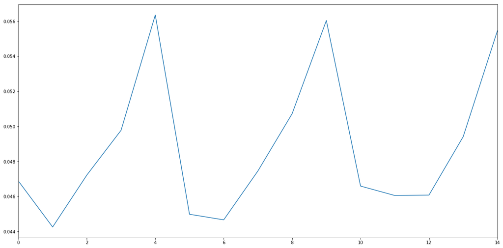

```python
results_df['r2'] = results_df.apply(lambda x: x['scores'][0], axis=1)
results_df['mre'] = results_df.apply(lambda x: x['scores'][1], axis=1)
# Pickle that!
results_df.to_pickle('../../data/results_ahead7_knn_df.pkl')
results_df['mre'].plot()

print('Minimum MRE param set: \n {}'.format(results_df.iloc[np.argmin(results_df['mre'])]))
print('Maximum R^2 param set: \n {}'.format(results_df.iloc[np.argmax(results_df['r2'])]))
```

### - Decision Tree model

```python
from predictor.decision_tree_predictor import DecisionTreePredictor

# Global variables
eval_predictor  = DecisionTreePredictor()
step_eval_days = 60  # The step to move between training/validation pairs


results_df = parallelize_dataframe(params_list_df, apply_mean_score_eval)
results_df
```

```
Generating: base7_ahead7_train252
Generating: base112_ahead7_train252
Generating: base56_ahead7_train504
Generating: base28_ahead7_train756
Evaluating approximately 87 training/evaluation pairs
Evaluating approximately 78 training/evaluation pairs
Evaluating approximately 85 training/evaluation pairs
Evaluating approximately 82 training/evaluation pairs
Approximately 29.5 percent complete.     (-1.0663848301487497, 0.06086374659275455)
Generating: base14_ahead7_train252
Evaluating approximately 87 training/evaluation pairs
Approximately 61.0 percent complete.     (-1.2558624229344277, 0.059827175577926314)
Generating: base28_ahead7_train252
Evaluating approximately 87 training/evaluation pairs
Approximately 50.6 percent complete.     (0.8210551041185481, 0.058772101448775378)
Generating: base7_ahead7_train504
Evaluating approximately 83 training/evaluation pairs
Approximately 30.1 percent complete.     (0.39163217165165864, 0.060686286092576765)
Generating: base56_ahead7_train756
Approximately 79.3 percent complete.    Evaluating approximately 78 training/evaluation pairs
Approximately 49.4 percent complete.     (0.6705802134468396, 0.059597549746133904)
Generating: base112_ahead7_train504
Approximately 96.6 percent complete.    Evaluating approximately 81 training/evaluation pairs
Approximately 55.4 percent complete.     (-0.001826307957646722, 0.061537329374190763)
Generating: base56_ahead7_train252
Evaluating approximately 86 training/evaluation pairs
Approximately 101.2 percent complete.    (-0.47766324009157091, 0.059806332388510061)
Generating: base14_ahead7_train504
Approximately 9.9 percent complete.     Evaluating approximately 83 training/evaluation pairs
Approximately 83.1 percent complete.     (0.50581234009906295, 0.06038222102350408)
Approximately 101.2 percent complete.    (-0.19540364229132198, 0.059511125485829729)
Generating: base28_ahead7_train504
Evaluating approximately 83 training/evaluation pairs
Approximately 91.0 percent complete.     (0.3001197300128543, 0.062997471554672294)
Approximately 101.3 percent complete.    (0.71973549121605185, 0.059074748536608303)
Generating: base112_ahead7_train756
Approximately 86.4 percent complete.    Evaluating approximately 77 training/evaluation pairs
Approximately 101.2 percent complete.    (0.82643865293305541, 0.060341249975678531)
Generating: base7_ahead7_train756
Evaluating approximately 79 training/evaluation pairs
Approximately 101.3 percent complete.    (-0.24814701292026495, 0.06182455486149744)
Generating: base14_ahead7_train756
Evaluating approximately 79 training/evaluation pairs
Approximately 100.0 percent complete.    (0.11806649940049044, 0.062738141490064944)
Approximately 101.3 percent complete.    (0.8493092183198796, 0.059612425038612082)
```

|  | base_days | ahead_days | train_val_time | step_days | GOOD_DATA_RATIO | SAMPLES_GOOD_DATA_RATIO | x_filename | y_filename | train_days | scores |
| --- | --- | --- | --- | --- | --- | --- | --- | --- | --- | --- |
| 0 | 7 | 7 | -1 | 7 | 0.99 | 0.9 | x_base7_ahead7.pkl | y_base7_ahead7.pkl | 252 | (-1.06638483015, 0.0608637465928) |
| 1 | 14 | 7 | -1 | 7 | 0.99 | 0.9 | x_base14_ahead7.pkl | y_base14_ahead7.pkl | 252 | (-1.25586242293, 0.0598271755779) |
| 2 | 28 | 7 | -1 | 7 | 0.99 | 0.9 | x_base28_ahead7.pkl | y_base28_ahead7.pkl | 252 | (-0.00182630795765, 0.0615373293742) |
| 3 | 56 | 7 | -1 | 7 | 0.99 | 0.9 | x_base56_ahead7.pkl | y_base56_ahead7.pkl | 252 | (0.505812340099, 0.0603822210235) |
| 4 | 112 | 7 | -1 | 7 | 0.99 | 0.9 | x_base112_ahead7.pkl | y_base112_ahead7.pkl | 252 | (0.821055104119, 0.0587721014488) |
| 5 | 7 | 7 | -1 | 7 | 0.99 | 0.9 | x_base7_ahead7.pkl | y_base7_ahead7.pkl | 504 | (-0.477663240092, 0.0598063323885) |
| 6 | 14 | 7 | -1 | 7 | 0.99 | 0.9 | x_base14_ahead7.pkl | y_base14_ahead7.pkl | 504 | (-0.195403642291, 0.0595111254858) |
| 7 | 28 | 7 | -1 | 7 | 0.99 | 0.9 | x_base28_ahead7.pkl | y_base28_ahead7.pkl | 504 | (0.300119730013, 0.0629974715547) |
| 8 | 56 | 7 | -1 | 7 | 0.99 | 0.9 | x_base56_ahead7.pkl | y_base56_ahead7.pkl | 504 | (0.670580213447, 0.0595975497461) |
| 9 | 112 | 7 | -1 | 7 | 0.99 | 0.9 | x_base112_ahead7.pkl | y_base112_ahead7.pkl | 504 | (0.826438652933, 0.0603412499757) |
| 10 | 7 | 7 | -1 | 7 | 0.99 | 0.9 | x_base7_ahead7.pkl | y_base7_ahead7.pkl | 756 | (-0.24814701292, 0.0618245548615) |
| 11 | 14 | 7 | -1 | 7 | 0.99 | 0.9 | x_base14_ahead7.pkl | y_base14_ahead7.pkl | 756 | (0.1180664994, 0.0627381414901) |
| 12 | 28 | 7 | -1 | 7 | 0.99 | 0.9 | x_base28_ahead7.pkl | y_base28_ahead7.pkl | 756 | (0.391632171652, 0.0606862860926) |
| 13 | 56 | 7 | -1 | 7 | 0.99 | 0.9 | x_base56_ahead7.pkl | y_base56_ahead7.pkl | 756 | (0.719735491216, 0.0590747485366) |
| 14 | 112 | 7 | -1 | 7 | 0.99 | 0.9 | x_base112_ahead7.pkl | y_base112_ahead7.pkl | 756 | (0.84930921832, 0.0596124250386) |

```
Minimum MRE param set:
 base_days                                                112
ahead_days                                                 7
train_val_time                                            -1
step_days                                                  7
GOOD_DATA_RATIO                                         0.99
SAMPLES_GOOD_DATA_RATIO                                  0.9
x_filename                              x_base112_ahead7.pkl
y_filename                              y_base112_ahead7.pkl
train_days                                               252
scores                     (0.821055104119, 0.0587721014488)
r2                                                  0.821055
mre                                                0.0587721
Name: 4, dtype: object
Maximum R^2 param set:
 base_days                                               112
ahead_days                                                7
train_val_time                                           -1
step_days                                                 7
GOOD_DATA_RATIO                                        0.99
SAMPLES_GOOD_DATA_RATIO                                 0.9
x_filename                             x_base112_ahead7.pkl
y_filename                             y_base112_ahead7.pkl
train_days                                              756
scores                     (0.84930921832, 0.0596124250386)
r2                                                 0.849309
mre                                               0.0596124
Name: 14, dtype: object
```

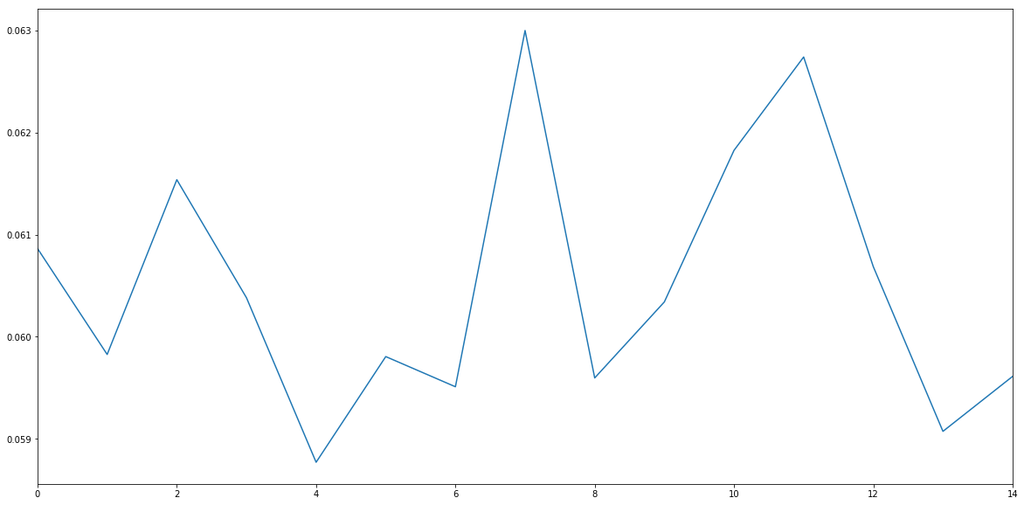

```python
results_df['r2'] = results_df.apply(lambda x: x['scores'][0], axis=1)
results_df['mre'] = results_df.apply(lambda x: x['scores'][1], axis=1)
# Pickle that!
results_df.to_pickle('../../data/results_ahead7_decision_tree_df.pkl')
results_df['mre'].plot()

print('Minimum MRE param set: \n {}'.format(results_df.iloc[np.argmin(results_df['mre'])]))
print('Maximum R^2 param set: \n {}'.format(results_df.iloc[np.argmax(results_df['r2'])]))
```

### - Random Forest model

```python
from predictor.random_forest_predictor import RandomForestPredictor

# Global variables
eval_predictor = RandomForestPredictor()
step_eval_days = 60  # The step to move between training/validation pairs


results_df = parallelize_dataframe(params_list_df, apply_mean_score_eval)
results_df
```

```
Generating: base7_ahead7_train252
Generating: base56_ahead7_train504
Generating: base28_ahead7_train756
Generating: base112_ahead7_train252
Evaluating approximately 87 training/evaluation pairs
Evaluating approximately 78 training/evaluation pairs
Evaluating approximately 82 training/evaluation pairs
Evaluating approximately 85 training/evaluation pairs
Approximately 101.1 percent complete.    (0.14010743951704019, 0.04533484495794507)
Generating: base14_ahead7_train252
Evaluating approximately 87 training/evaluation pairs
Approximately 101.1 percent complete.    (0.28926887493199832, 0.043739167047868031)
Generating: base28_ahead7_train252
Evaluating approximately 87 training/evaluation pairs
Approximately 101.1 percent complete.    (0.62562935264717001, 0.046035135749556096)
Generating: base56_ahead7_train252
Approximately 51.2 percent complete.    Evaluating approximately 86 training/evaluation pairs
Approximately 101.2 percent complete.    (0.8927463715086168, 0.044991622221713608)
Generating: base7_ahead7_train504
Evaluating approximately 83 training/evaluation pairs
Approximately 101.3 percent complete.    (0.69208355759904683, 0.045122741552250357)
Generating: base56_ahead7_train756
Evaluating approximately 78 training/evaluation pairs
Approximately 101.2 percent complete.    (0.77227401591658074, 0.045326783620015361)
Approximately 101.2 percent complete.    (0.12611922641374829, 0.04484525688089426)
Generating: base14_ahead7_train504
Evaluating approximately 83 training/evaluation pairs
Approximately 101.2 percent complete.    (0.84510076679537582, 0.043284313314381172)
Generating: base112_ahead7_train504
Evaluating approximately 81 training/evaluation pairs
Approximately 101.2 percent complete.    (0.5068675871794438, 0.043638274081193258)
Generating: base28_ahead7_train504
Evaluating approximately 83 training/evaluation pairs
Approximately 100.0 percent complete.    (0.67923311433963918, 0.047542863229662613)
Approximately 101.3 percent complete.    (0.84342388052506079, 0.043710443309204268)
Generating: base112_ahead7_train756
Evaluating approximately 77 training/evaluation pairs
Approximately 101.2 percent complete.    (0.89055689093748902, 0.044696894237971303)
Generating: base7_ahead7_train756
Evaluating approximately 79 training/evaluation pairs
Approximately 101.3 percent complete.    (0.30285826277496275, 0.046504893287340233)
Generating: base14_ahead7_train756
Evaluating approximately 79 training/evaluation pairs
Approximately 100.0 percent complete.    (0.51780910383087297, 0.046584482620645212)
Approximately 101.3 percent complete.    (0.91504823085856357, 0.044266994851520018)
```

|  | base_days | ahead_days | train_val_time | step_days | GOOD_DATA_RATIO | SAMPLES_GOOD_DATA_RATIO | x_filename | y_filename | train_days | scores |
| --- | --- | --- | --- | --- | --- | --- | --- | --- | --- | --- |
| 0 | 7 | 7 | -1 | 7 | 0.99 | 0.9 | x_base7_ahead7.pkl | y_base7_ahead7.pkl | 252 | (0.140107439517, 0.0453348449579) |
| 1 | 14 | 7 | -1 | 7 | 0.99 | 0.9 | x_base14_ahead7.pkl | y_base14_ahead7.pkl | 252 | (0.289268874932, 0.0437391670479) |
| 2 | 28 | 7 | -1 | 7 | 0.99 | 0.9 | x_base28_ahead7.pkl | y_base28_ahead7.pkl | 252 | (0.625629352647, 0.0460351357496) |
| 3 | 56 | 7 | -1 | 7 | 0.99 | 0.9 | x_base56_ahead7.pkl | y_base56_ahead7.pkl | 252 | (0.772274015917, 0.04532678362) |
| 4 | 112 | 7 | -1 | 7 | 0.99 | 0.9 | x_base112_ahead7.pkl | y_base112_ahead7.pkl | 252 | (0.892746371509, 0.0449916222217) |
| 5 | 7 | 7 | -1 | 7 | 0.99 | 0.9 | x_base7_ahead7.pkl | y_base7_ahead7.pkl | 504 | (0.126119226414, 0.0448452568809) |
| 6 | 14 | 7 | -1 | 7 | 0.99 | 0.9 | x_base14_ahead7.pkl | y_base14_ahead7.pkl | 504 | (0.506867587179, 0.0436382740812) |
| 7 | 28 | 7 | -1 | 7 | 0.99 | 0.9 | x_base28_ahead7.pkl | y_base28_ahead7.pkl | 504 | (0.67923311434, 0.0475428632297) |
| 8 | 56 | 7 | -1 | 7 | 0.99 | 0.9 | x_base56_ahead7.pkl | y_base56_ahead7.pkl | 504 | (0.845100766795, 0.0432843133144) |
| 9 | 112 | 7 | -1 | 7 | 0.99 | 0.9 | x_base112_ahead7.pkl | y_base112_ahead7.pkl | 504 | (0.890556890937, 0.044696894238) |
| 10 | 7 | 7 | -1 | 7 | 0.99 | 0.9 | x_base7_ahead7.pkl | y_base7_ahead7.pkl | 756 | (0.302858262775, 0.0465048932873) |
| 11 | 14 | 7 | -1 | 7 | 0.99 | 0.9 | x_base14_ahead7.pkl | y_base14_ahead7.pkl | 756 | (0.517809103831, 0.0465844826206) |
| 12 | 28 | 7 | -1 | 7 | 0.99 | 0.9 | x_base28_ahead7.pkl | y_base28_ahead7.pkl | 756 | (0.692083557599, 0.0451227415523) |
| 13 | 56 | 7 | -1 | 7 | 0.99 | 0.9 | x_base56_ahead7.pkl | y_base56_ahead7.pkl | 756 | (0.843423880525, 0.0437104433092) |
| 14 | 112 | 7 | -1 | 7 | 0.99 | 0.9 | x_base112_ahead7.pkl | y_base112_ahead7.pkl | 756 | (0.915048230859, 0.0442669948515) |

```
Minimum MRE param set:
 base_days                                                 56
ahead_days                                                 7
train_val_time                                            -1
step_days                                                  7
GOOD_DATA_RATIO                                         0.99
SAMPLES_GOOD_DATA_RATIO                                  0.9
x_filename                               x_base56_ahead7.pkl
y_filename                               y_base56_ahead7.pkl
train_days                                               504
scores                     (0.845100766795, 0.0432843133144)
r2                                                  0.845101
mre                                                0.0432843
Name: 8, dtype: object
Maximum R^2 param set:
 base_days                                                112
ahead_days                                                 7
train_val_time                                            -1
step_days                                                  7
GOOD_DATA_RATIO                                         0.99
SAMPLES_GOOD_DATA_RATIO                                  0.9
x_filename                              x_base112_ahead7.pkl
y_filename                              y_base112_ahead7.pkl
train_days                                               756
scores                     (0.915048230859, 0.0442669948515)
r2                                                  0.915048
mre                                                 0.044267
Name: 14, dtype: object
```

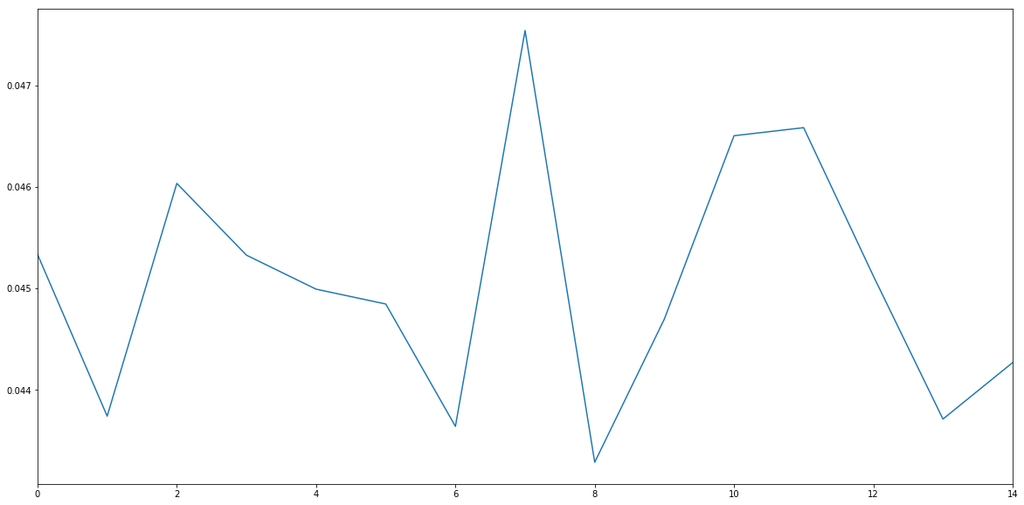

```python
results_df['r2'] = results_df.apply(lambda x: x['scores'][0], axis=1)
results_df['mre'] = results_df.apply(lambda x: x['scores'][1], axis=1)
# Pickle that!
results_df.to_pickle('../../data/results_ahead7_random_forest_df.pkl')
results_df['mre'].plot()

print('Minimum MRE param set: \n {}'.format(results_df.iloc[np.argmin(results_df['mre'])]))
print('Maximum R^2 param set: \n {}'.format(results_df.iloc[np.argmax(results_df['r2'])]))
```